# Curso 6 Inferencia estadística

## VARIABLES INDEPENDIENTES

Dos variables son independientes si la ocurrencia de una no tiene nada que ver en la ocurrencia de otra.

Por ejemplo tirar dos veces una moneda y que salga las dos cara, son sucesos independientes 0.5x0.5 = 0.25

Si los sucesos no son independientes la intersección de las probabilidades no se pueden calcular multiplicando.

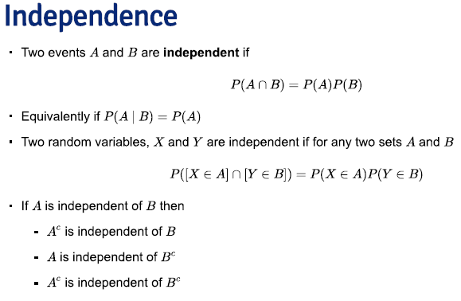

qownnotes-media-edrncZ

Todos los estudios que realizamos no sólo están basados en sucesos independientes, si no que además están identicamente distribuidos, IID variables

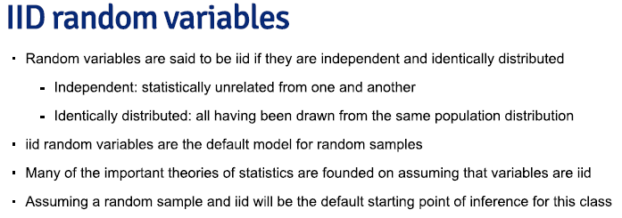

qownnotes-media-GvDchr

## VALOR ESPERADO O ESPERANZA MATEMATICA(Centro geométrico de las Áreas de probabilidad) o MEDIA

Se insiste mucho en la diferencia entre muestra y población. En este caso cuando hagamos cálculos sobre una muestra haremos los cálculos en base a los valores encontrados en esa muesta (Ej:tiro un dado 10 veces y salen 2 1s, 3 2s, 1 3, 4 5s.). Cuando se habla sobre los cáculos sobre una población estaremos hablando sobre las probabilidades que tenga una variable de tomar un valor sin haber realizado muestras ( o lo que es lo mismo si hubiéramos hecho infinitas muestras)

MEDIA DE UNA MUESTRA Es la suma de todos los valores dividido por el número de muestras TirarDado = {1,1,5,4,3,4,6,5,4,6} _ x = (1+1+5+4+3+4+6+5+4+6)/10 = 3.9

MEDIA DE UNA POBLACIÓN Es una propiedad de las distribuciones de probabilidad de la misma manera que lo son la mediana (valor del punto que está en la mitad) y la varianza

En variables **discretas** será el valor de su probabilidad multiplicado por el propio valor

E(x)= x1*P(x1)+x2*P(x2)+…

```
$$
E[X] = 1 \times \frac{1}{6} + 2 \times \frac{1}{6} +
3 \times \frac{1}{6} + 4 \times \frac{1}{6} +
5 \times \frac{1}{6} + 6 \times \frac{1}{6} = 3.5
$$
```

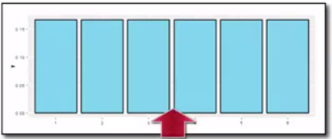

qownnotes-media-S12388

En variables **contínuas**, tenemos que hacer uso de la función de distribución para recoger la probabilidad acumulada.(dx)

E(x) = Integral (x*f(x)* d(x))

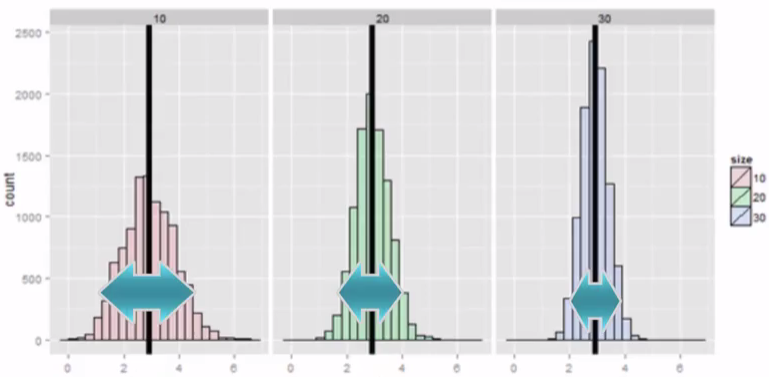

qownnotes-media-z14800

MEDIA DE MÚLTIPLES MUESTRAS

La media de un conjunto de muestras es en sí también una variable aleatoria, de la que podríamos calcular su media y su varianza ( la media de las medias y la varianza de las medias). _ E(x) = suma x / n

## VARIABILIDAD

VARIANZA DE UNA MUESTRA Es la suma de la distancia de todos los puntos de la muestra respecto a la media (se pone al cuadrado para evitar distancias negativas y calcular su distancia absoluta)

S = Desviación estándar –> Se aplica a raiz cuadrada para que esté en las mismas unidades que el resto.

VARIANZA DE UNA POBLACIóN Varianza: es la dispersión de los datos respecto a la media.

Var(X) = E(X-mu)^2 (Mide la distancia de todos los puntos con respecto a la media, al cuadrado para que sean distancias absolutas) sd(X) = sqrt(var(x)) Desviación estándar es la raíz cuadrada de la varianza de manera que el dato está en las mismas unidades que el eje de las X, lo cual es muy útil.

En el caso del ejemplo:Var(X) = E(x)^2 - mu^2

mu^2 = 3.5^2 = 12,25

Var(X) = 15.17-12.25 = 2.92

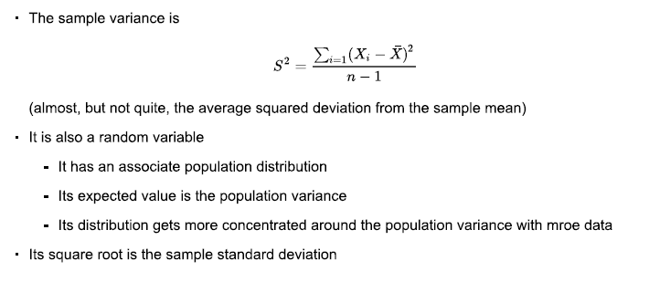

qownnotes-media-dfmfMN

En el caso de la varianza de las muestras hay una pequeña variación ya que se divide por n-1. Esto es debido a que las primeras n-1 observaciones son son independientes de la media. la úiltima no es independiente ya que puede ser calculada por medio de la media de la muestra usada en la formula. En otras palabras, la varianza de la muestra es CASI la media de la desviación al cuadrado de la media de la muestra. _ Var(x) suma var(x) /n-1

La distribución de la varianza de las muestras también se verá afectado por el tamaño de la muestra, de manera que a mayor tamaño de la muestra la curva se irá acercando a la variaza de la población que está intentando estimar:

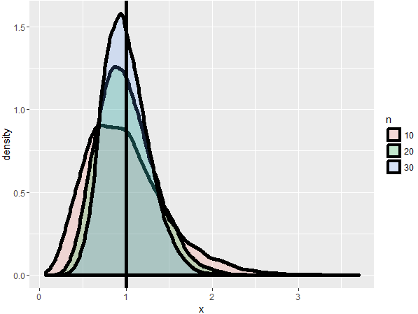

qownnotes-media-M19368

VARIANZA DE MÚLTIPLES MUESTRAS

La desviación estándar de una una estadística se llama error estándar y es la varianza dividido el número de muestras, o lo que es lo mismo la desviación estándar dividido raíz cuadrada del número de muestas (numerador y denominador aplicados la raíz cuadrada)

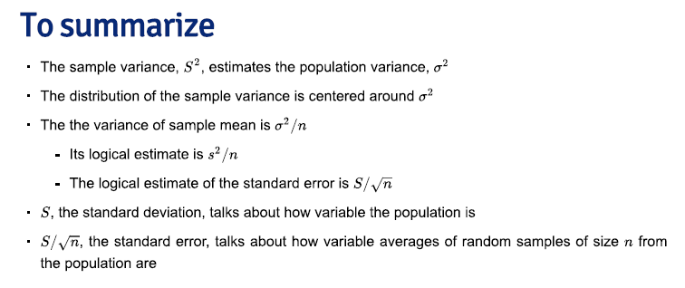

qownnotes-media-CiZnlf

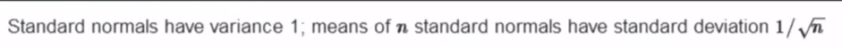

qownnotes-media-A14800

## MEDIA Y DESVIACIÓN ESTANDAR (ERROR ESTANDAR) DE MÚLTIPLES MUESTRAS

Si simulamos con R 1000 muestras de una distribción normal con 10 valores posibles vemos que se acerca mucho a lo calculado para la población, y cuanto más se aumenten las muestras más cerca estará ese valor:

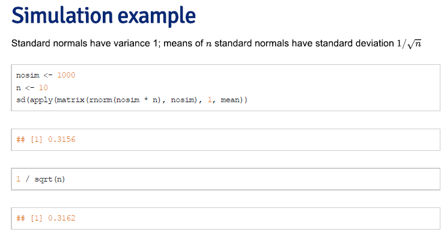

qownnotes-media-RlgzCm

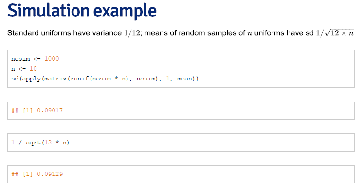

qownnotes-media-hYQmGV

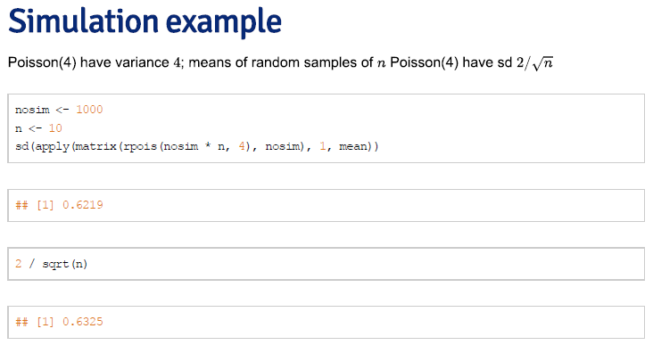

qownnotes-media-KWuTdE

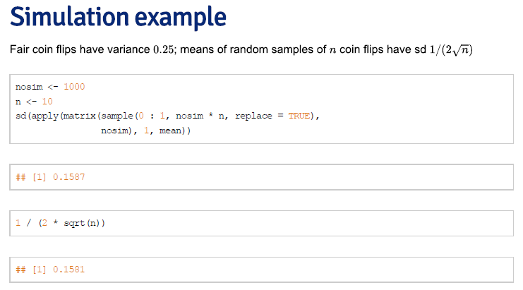

Hay una medida adicional que es el coeficiente de dispersión de Pearson, que es la desviación típica dividida por su media, de esta manera podemos medir la dispersión de dos variables de distintas unidades. Por ejemplo, comparar la dispersóin del peso de los niños de una clase frente a la altura de otra clase.

El índice de Gini también nos puede servir para medir cómo de concentrados están los datos

El coeficiente de Fisher nos dice cómo de asimétrica es la curva de distribución.

La courtosis es cómo de aglutinados están las frecuencias alrededor de la media.

## EJEMPLOS CON DISTRIBUCIONES

**BERNULLI**

Si X es una variable aleatoria que mide el número de éxitos, y se realiza un único experimento con dos posibles resultados (éxito o fracaso), se dice que la variable aleatoria X se distribuye como una Bernoulli de parámetro p. (Ejemplo tirar 1 moneda 1 vez y que salga cruz)

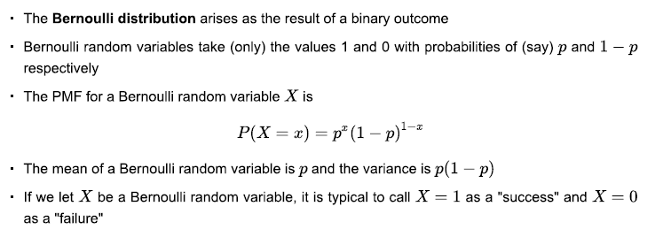

qownnotes-media-MnhxZU

Si hacemos varias observaciones de Bernuilli pongamos $x_1,\ldots, x_n$ , la posibilidad (likelihood)de que el evento sea éxito es
$$\prod_{i=1}^n p^{x_i} (1 - p)^{1 - x_i} = p^{\sum x_i} (1 - p)^{n - \sum x_i}$$
$\hat p = \sum_i x_i / n$ es el máximo estimador de posibilidad para $p$

Todas las posibilidades para n pequeña

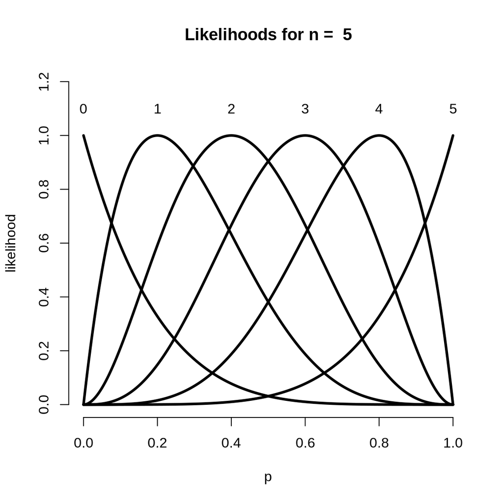

**BINOMIAL**

cuenta el número de éxitos en una secuencia de n ensayos de Bernoulli independientes entre sí, con una probabilidad fija p de ocurrencia del éxito entre los ensayos. Un experimento de Bernoulli se caracteriza por ser dicotómico, esto es, solo dos resultados son posibles

Para n = 1, la binomial se convierte, de hecho, en una distribución de Bernoulli.

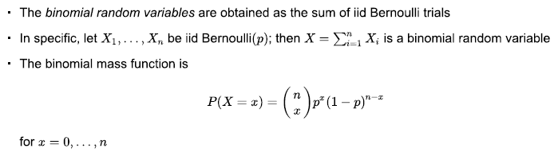

qownnotes-media-zTNfQz

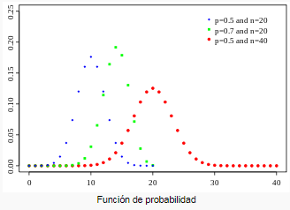

qownnotes-media-dnOuDU

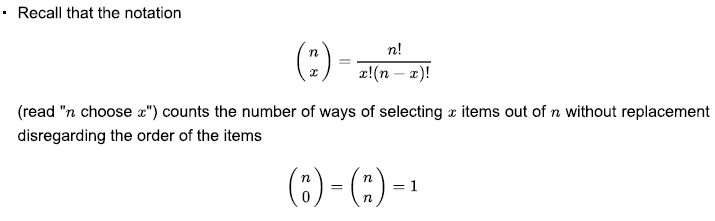

qownnotes-media-mjITSs

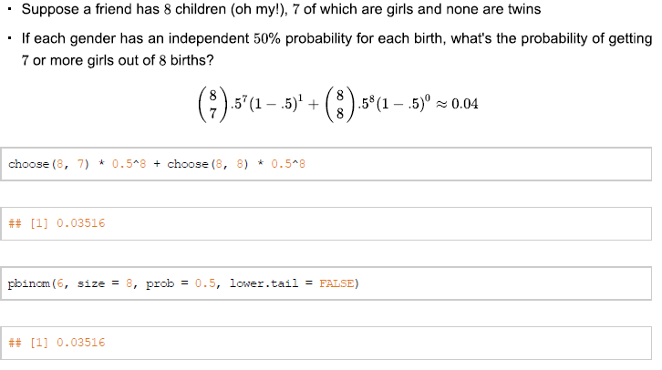

qownnotes-media-fjsoAv

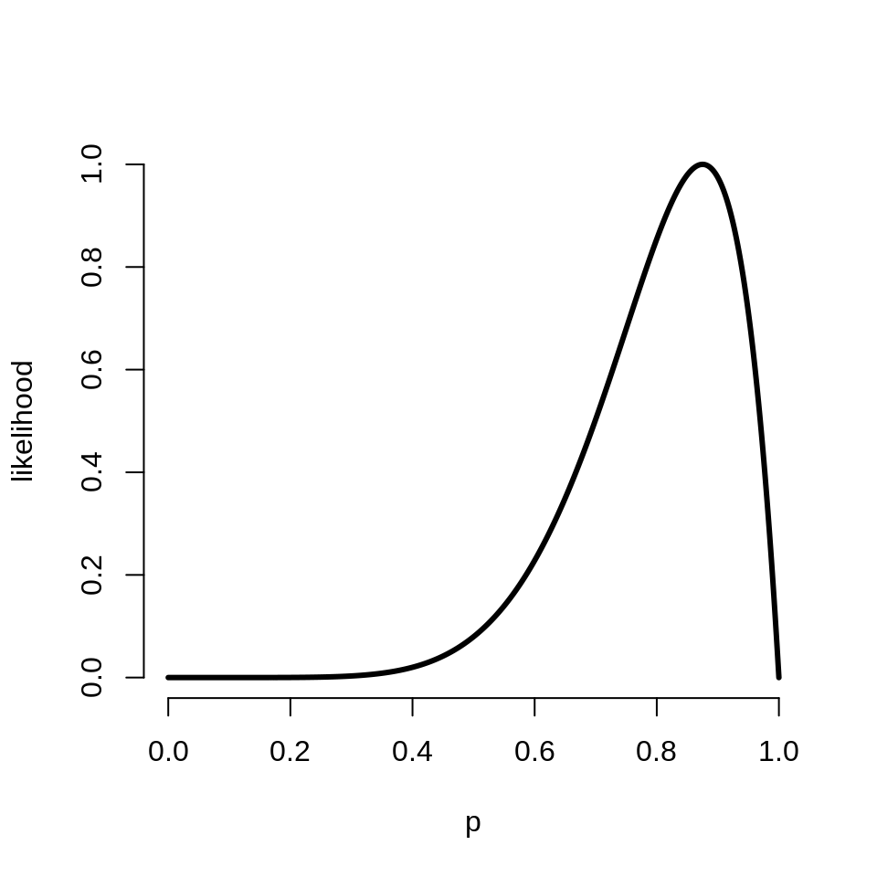

```r
plot(pvals, dbinom(7, 8, pvals) / dbinom(7, 8, 7/8) ,
     lwd = 3, frame = FALSE, type = "l", xlab = "p", ylab = "likelihood")
```

**DISTRIBUCION NORMAL ESTANDAR**

Es una distribución normal pero con la particularidad de que tiene mu = 0 y sigma = 1

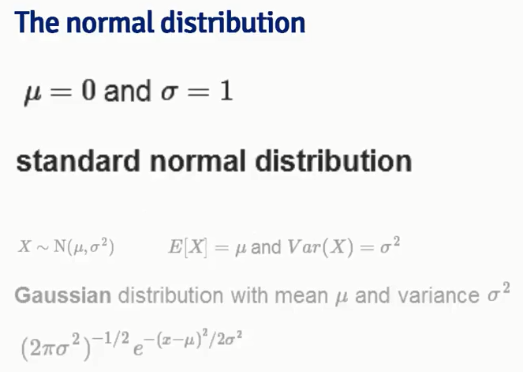

qownnotes-media-BjqEKS

De manera que 1 desviación estandar recoge el 68% de los datos, 2 desviaciones estándar el 95% y 3 desviaciones estandar el 99%.

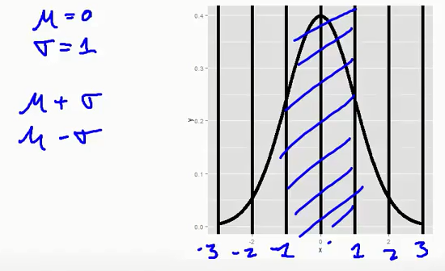

qownnotes-media-SIFoSu

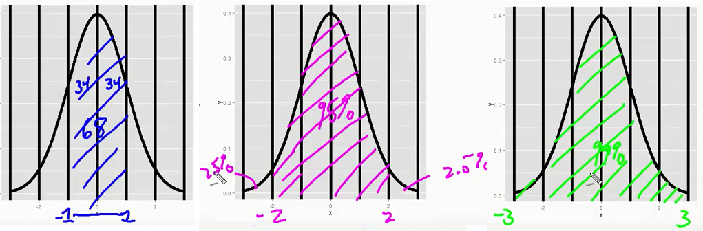

qownnotes-media-hjbGgE

**DISTRIBUCION NORMAL**

Por tanto una distribucion normal tendrá mu != 0 y sigma != 1, la única diferencia con los gráficos anteriores es que no estará centrada en 0, y que los ejes de las x cada 1,2 y 3 estar? multiplicado por su sigma.

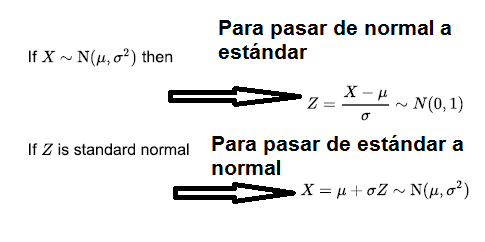

qownnotes-media-mAfrpi

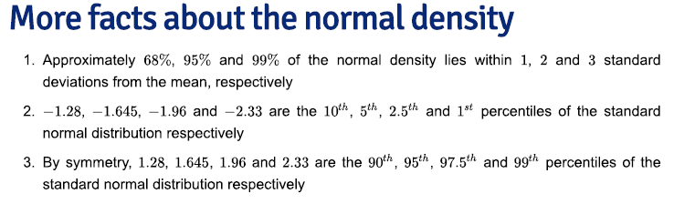

qownnotes-media-kOrKhD

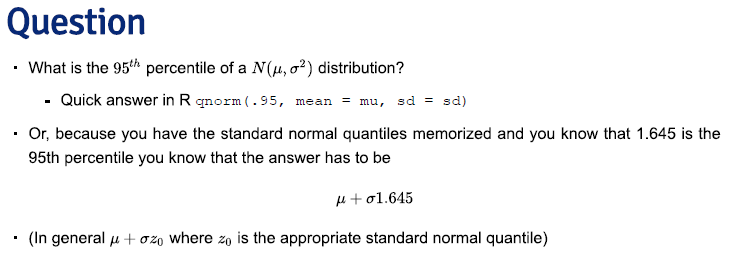

qownnotes-media-RxbLpG

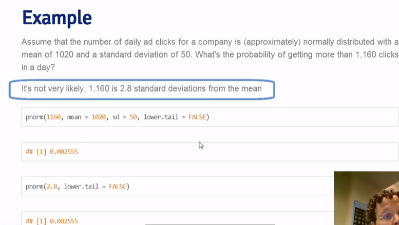

qownnotes-media-R14800

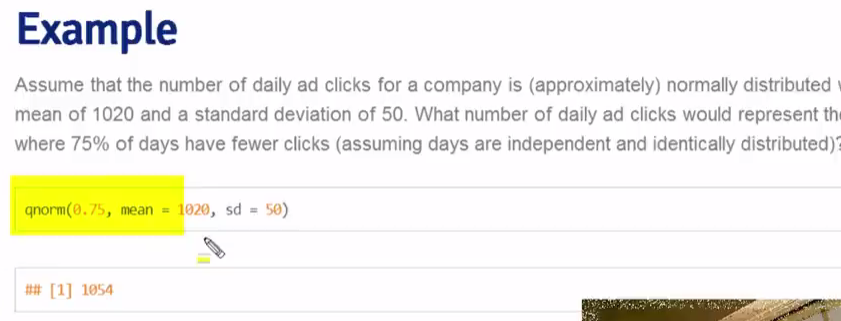

qownnotes-media-B14800

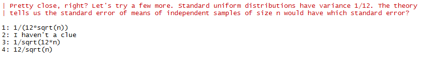

qownnotes-media-P19368

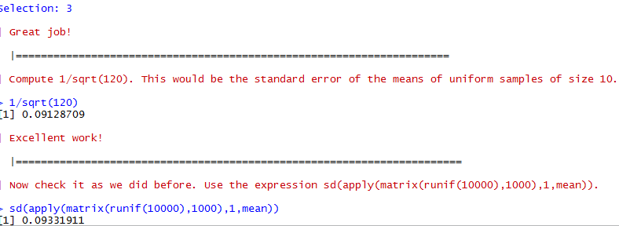

qownnotes-media-L19368

**POISSON**

expresa, a partir de una frecuencia de ocurrencia media, la probabilidad de que ocurra un determinado n?mero de eventos durante cierto periodo de tiempo. Concretamente, se especializa en la probabilidad de ocurrencia de sucesos con probabilidades muy peque?as, o sucesos “raros”.

Tanto el valor esperado como la varianza de una variable aleatoria con distribución de Poisson son iguales

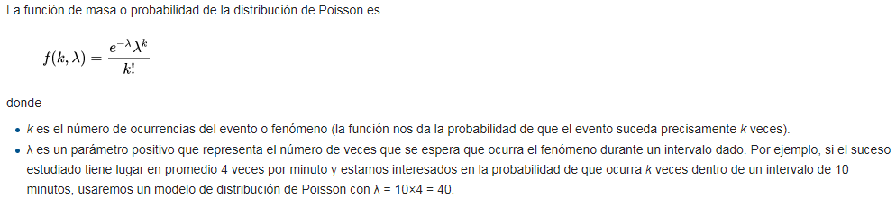

qownnotes-media-mMWyDG

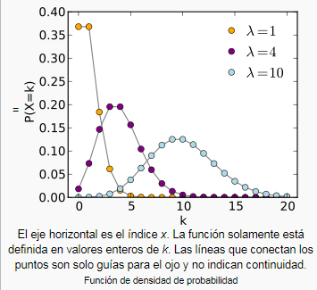

qownnotes-media-BmoCZj

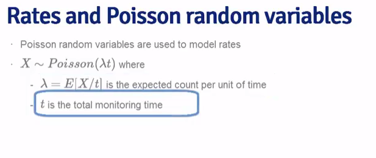

qownnotes-media-Y14800

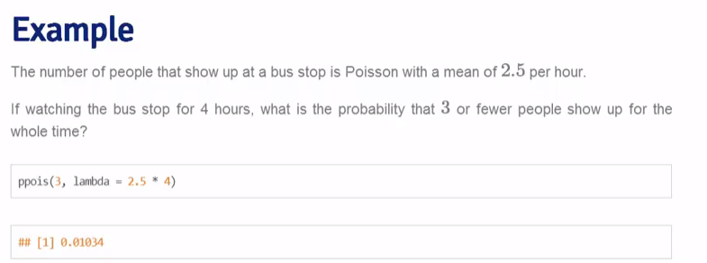

qownnotes-media-i14800

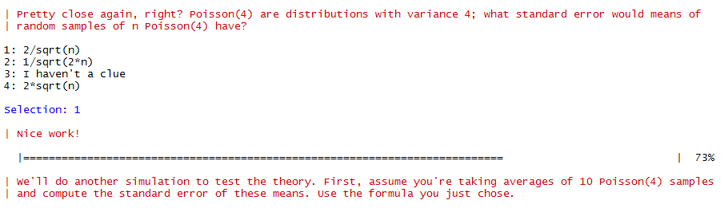

qownnotes-media-i19368

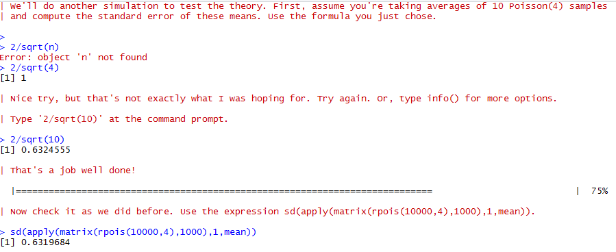

qownnotes-media-u19368

Es muy útil para:

*Conteos de datos Cuantas veces se repite un determinado evento.

*Modelar eventos de tiempo o de supervivencia, que modeliza el tiempo que se tarda en que ocurra un determinado suceso. Por el nombre de la técnica parecería que se analizara el tiempo hasta la muerte (Análisis de supervivencia) pero, en realidad, puede analizarse cualquier otro suceso.

En Análisis de supervivencia la muestra consiste en el seguimiento de una serie de individuos desde el inicio del estudio hasta su final y, ante una situación de este tipo, es frecuente que se produzca la desaparición de alguno de esos individuos que entran en el estudio. También es posible que al entrar un individuo en el estudio, éste termine antes de que en ese individuo se produzca el suceso que se pretende detectar. Un ejemplo es el tiempo en que cominezan a aparecer determinados sintomas en pacientes sanos:

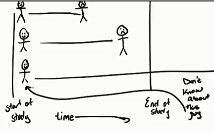

*Para modelar tablas de contingencia.Modelando tablas de contingencia (cruzar dos características y ver el número de casos que pertenecen a cada categoria)

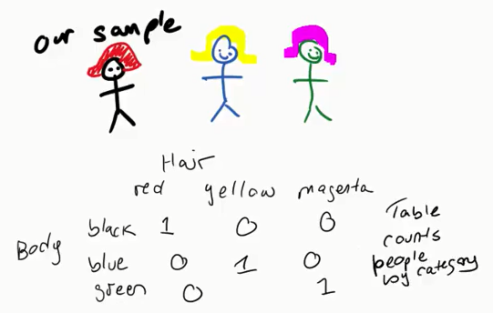

qownnotes-media-uSdaBj

*Aproximaciones binomiales cuando n es muy grande y p muy pequeño, por ejemplo en epidemiología el tener o no tener una enfermedad sobre una población.

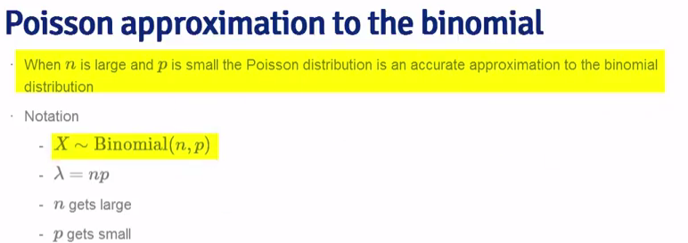

qownnotes-media-p14800

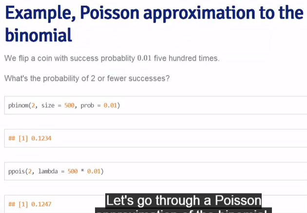

qownnotes-media-l14800

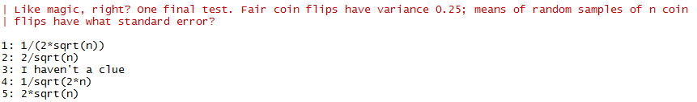

qownnotes-media-n19368

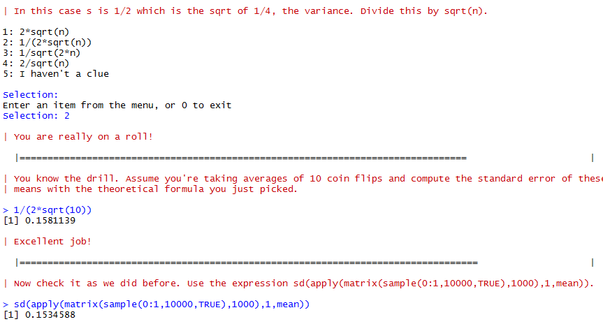

qownnotes-media-m19368

## ESTUDIO ASINTÓTICO

Es el término para el análisis del comportamiento de las estadísticas cuando el tamaño de la muestra tiene un límite (normalmente infinito). Es la base de estudio frecuentista de probabilidades.

Un estimador es consistente si converge con lo que queremos estimar. La ley de números largos (LLN) dice que la media de la muestra, la varianza y la desviación estandar de iid muestras es consistente con la media de la población, la varianza y la desviación estándar respectivamente.

Teorema central del limite (CLT) : dice que la distribución de las medias siguen una distribución normal estándar centrada en el origen (ya que estamos restando la media de la población), con una desviación estándar igual al error estándar de la media, pero debe ser para un número de repeticiones suficiente como para que se cumpla.

$X_1,\ldots,X_n$ es una colección de variables aleatorias iid con media $\mu$ y varianza $\sigma^2$ $\bar X_n$ es la media de la muestra Entonces $\frac{\bar X_n - \mu}{\sigma / \sqrt{n}}$ tiene una distribución **normal** para largos $n$.

Por ejemplo, si tiramos un dado muchas veces y hacemos n observaciones

$\frac{\bar X_n - 3.5}{1.71/\sqrt{n}}$

Se ve claramente la dierencia de hacer 1,2 y 6 tiradas 10000 veces. La curva normal estándar lógicamente va a estar centrada en el origen ya que le estamos restando la media.

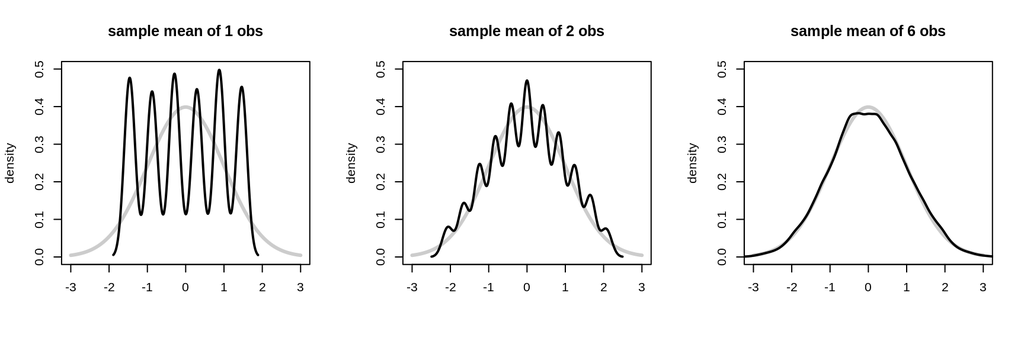

Al seguir una distribución normal, podemos usar los cuantiles para saber con qué probabilidad la media obtenida estará incluida en ese intervalo, para una distrióbucin normal sabemos
$$\bar X_n \pm z_{1-\alpha/2}\sigma / \sqrt{n}$$
y lo llamaremos intervalo de confianza.

En este ejemplo de las alturas de los hijos, podemos dar un intervalo de confianza en el cuál con un 95% de posibilidades la media obtenida en la muestra está contenida en la media de la población:

```r
library(UsingR);data(father.son); x <- father.son$sheight
(mean(x) + c(-1, 1) * qnorm(.975) * sd(x) / sqrt(length(x))) / 12
```

```
## [1] 5.709670 5.737674
```

Esta misma operación la podemos hacer con **Bernuilli** para proporciones de éxito o fallo:

$$\hat p \pm z_{1 - \alpha/2} \sqrt{\frac{p(1 - p)}{n}}$$
Sabiendo que la moneda es imparcial, p = 1/2, p(1-p)=1/4 y sqrt(p(1-p)) = 1/2

Aplicando le intervalor Wald del 95%

$p(1-p) \leq 1/4$ for $0 \leq p \leq 1$ $\alpha = .05$ so that $z_{1 -\alpha/2} = 1.96 \approx 2$
$$2 \sqrt{\frac{p(1 - p)}{n}} \leq 2 \sqrt{\frac{1}{4n}} = \frac{1}{\sqrt{n}}$$
Entonces $\hat p \pm \frac{1}{\sqrt{n}}$ es un buen intervalo de confianza rápido para $p$

Un ejemplo, es que en un sondeo de 100 personas, 56 votan sí, tengo la votación ganada? `1/sqrt(100)=.1` esto nos da un intervalo de confianza de Wald (95%) de entre `(0.46, 0.66)` así que no tenemos nada claro.

```r
(0.56 + c(-1, 1) * qnorm(.975) * sqrt(0.56*0.44/100))
```

```
## [1] 0.4627099 0.6572901
```

```r
binom.test(56,100)$conf.int
```

```
## [1] 0.4571875 0.6591640
## attr(,"conf.level")
## [1] 0.95
```

Si el proceso no fuera parcial (p=0.9 por ejemplo) el CTL nos garantiza únicamente que es una buena aproximación en el límite, pero se puede observar que si hacemos la misma prueba que con p = 0.5 tardan muchas más iteraciones en converger hacia una normal estándar.

Hay veces que el intervalo de wald no se comporta de manera correcta si el número de repeticiones no es el adecuado, y para evitarlo se puede aplicar la **corrección de Agresti/Coull** añadiendo dos aciertos y dos errores $p = X_n +2 / n+4 $

Por último si se trata de una distribución de Poisson por ejemplo para conteos:

Vemos que damos un un error diagnóstico 5 veces cada 94.32 días, cuál es el porcentaje de fallo diario con un intervalo de confianza dentro del 95%?

$X \sim Poisson(\lambda t)$ Estimate $\hat \lambda = X/t$ $Var(\hat \lambda) = \lambda / t$

$$\frac{\hat \lambda - \lambda}{\sqrt{\hat \lambda / t}}
=
\frac{X - t \lambda}{\sqrt{X}}
\rightarrow N(0,1)$$

```r
x <- 5
t <- 94.32
lambda <- x/t
round(lambda + c(-1, 1) * qnorm(.975) * sqrt(lambda/t),3 )
```

```
## [1] 0.007 0.099
```

```r
poisson.test(5,94.32)$conf.int
```

```
## [1] 0.01721254 0.12371005
## attr(,"conf.level")
## [1] 0.95
```

En este caso podemos observar que el intervalo calculado es más conservador ya que t no es lo suficientemente grande.

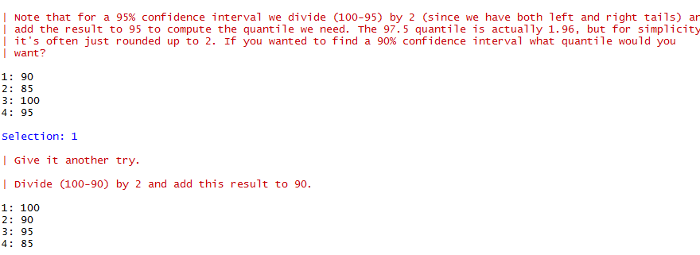

qownnotes-media-bG7876

Hay veces que el número de repeticiones no es suficiente en distribuciones discretas binomiales y de Poisson y se puede hacer una aproximación del valor estimado sumando +2 al numerador y +4 al denominador (añadiendo 2 exitos y 2 fallos)

[figure not shown]

qownnotes-media-jY7876

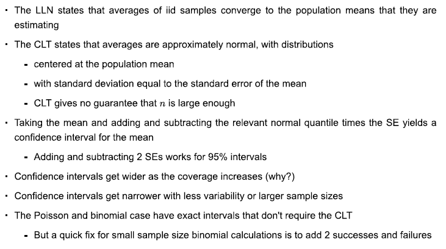

qownnotes-media-ZUuUAB

## INTERVALOS DE CONFIANZA

Por tanto, al seguir una normal estandar, el desplazamiento desde la media de 2 unidades del error estándar nos dará un intervalo en el que tendremos la probabilidad del 95% de contener el valor medio. A este intervalo lo llamamos ZQuantile X SE

$\bar X_n \pm 2\sigma / \sqrt{n}$ es el llamado intervalo 95% de $\mu$

En la vida real, las muestras con las que trabajamos no suelen ser tan grandes, por lo que necesitamos una adaptación, utilizando la distribución T Student de Gosset. surge del problema de estimar la media de una población normalmente distribuida cuando el tamaño de la muestra es pequeño. Está también centrada en 0. Si no fuera simétrica en 0 (skewed distr) habría que calculalo de otra manera o coger otro estimador como la mediana

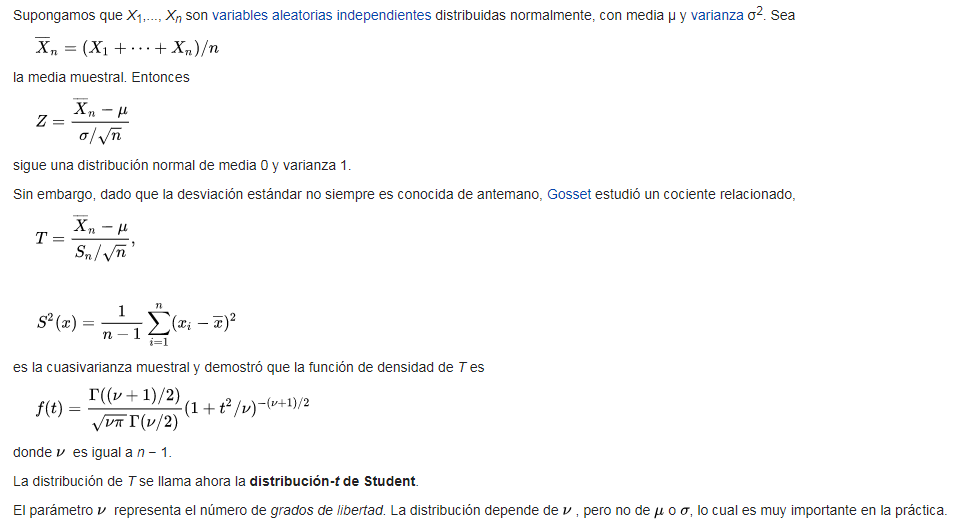

qownnotes-media-WYnisx

Aparece de manera natural al realizar la prueba t de Student para la determinación de las diferencias entre dos medias muestrales y para la construcción del intervalo de confianza para la diferencia entre las medias de dos poblaciones cuando se desconoce la desviación típica de una población y ésta debe ser estimada a partir de los datos de una muestra.

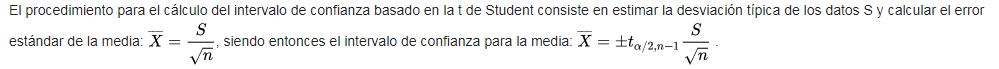

qownnotes-media-MIqXgZ

En adelante vamos a ver pequeñas muestras de datos y en este caso tendremos que usar la distribución T de Gosset y intervalos de confianza T, la única diferencia con la ecuación anterior es que usaremos el TQuantile

Cuando una distribución T creece y crece en muestras se acaba convirtiendo en distribución Z.

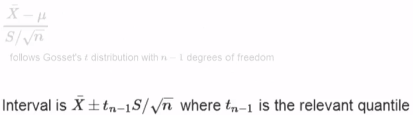

qownnotes-media-KN1524

El valor de esta t nos dará un intervalo de confianza, para el cuál dependiendo del número de individuos, en 95% de los casos ese valor está incluido, en el caso de que quisiéramos usar ese quantil qt(0.975,n)

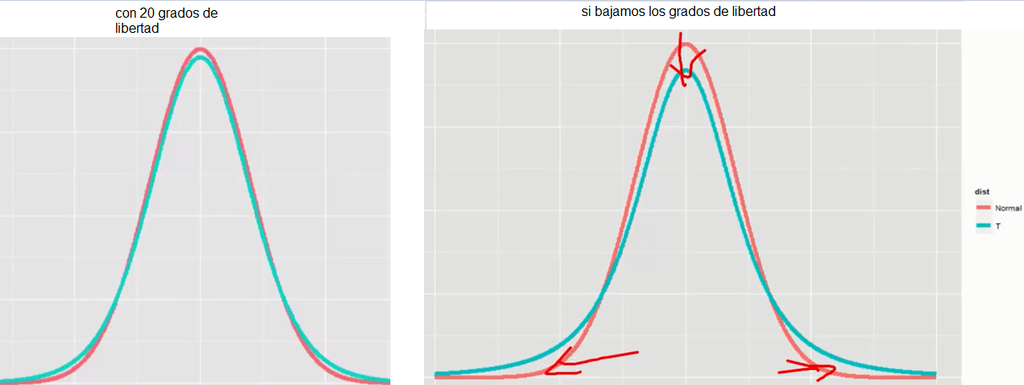

qownnotes-media-ASAszo

La distribución T es muy útil cuando queremos comparar cómo varía un grupo frente a otro, pero siempre teniendo en cuenta que deben ser datos iid normales, centrados en su media

Vamos a coger dos grupos y vamos a estudiar la diferencia de variabilidad entre ellos, primero estando relaccionados (que los individuos sean los mismos, y queremos ver su evolución) y luego siendo grupos independientes (Son grupos de personas totalmente distintas) .

Esa diferencia de variabilidad estará encerrada en un intervalo de confianza y se suele utilizar el intervalo T para compararlos

Los resultados del estudio por tanto varían dependiendo de si se emparejan los resultados porque están relaccionados o son independientes: Los datos son un grupo de 10 pacientes a los que se les ha tratado con 2 drogas distintas y se intenta comparar los resultados

```r
data(sleep)
sleep
```

```
##    extra group ID
## 1    0.7     1  1
## 2   -1.6     1  2
## 3   -0.2     1  3
## 4   -1.2     1  4
## 5   -0.1     1  5
## 6    3.4     1  6
## 7    3.7     1  7
## 8    0.8     1  8
## 9    0.0     1  9
## 10   2.0     1 10
## 11   1.9     2  1
## 12   0.8     2  2
## 13   1.1     2  3
## 14   0.1     2  4
## 15  -0.1     2  5
## 16   4.4     2  6
## 17   5.5     2  7
## 18   1.6     2  8
## 19   4.6     2  9
## 20   3.4     2 10
```

En las siguientes gráficas se ven cada uno de los valores de ambos resultados, estando la leyenda la correspondencia entre el color de la raya que une a los individuos y el número de individuo que es en el grupo

DEPENDIENTES (paired=TRUE)

[output not shown]

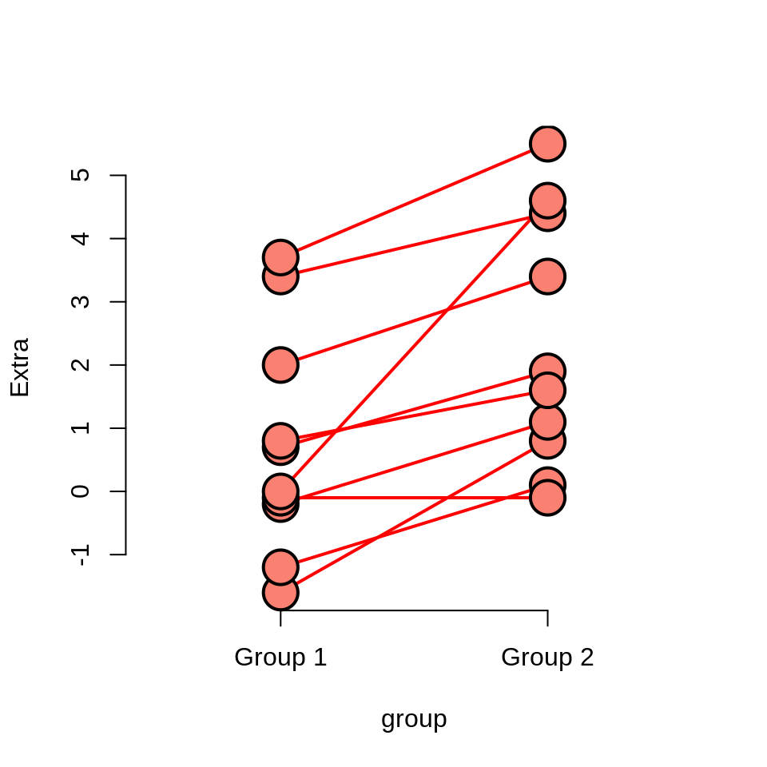

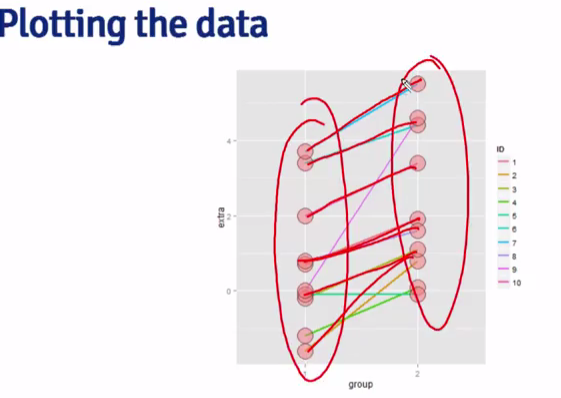

qownnotes-media-JY1524

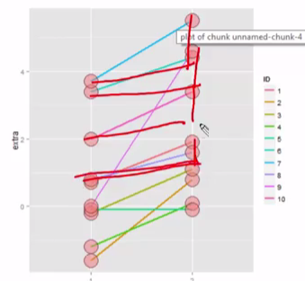

qownnotes-media-rV1524

Si queremos calcular el intevalo de confianza de los resultados emparejados, creamos un vector nuevo con la diferencia de los resultados de ambos grupos difference <- g2-g1

y se calcula la media y la desviación estandar mn <- mean(difference) s <- sd(difference) Los calculos se pueden hacer a mano mn + c(1,-1)*qt(.975)*(s/sqrt(10)) o con la función t.test()

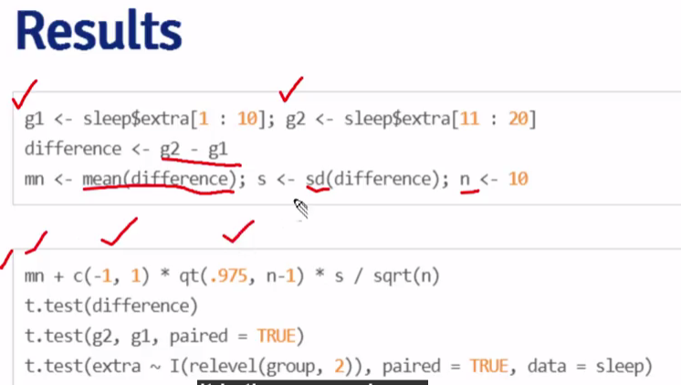

qownnotes-media-qs1524

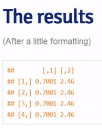

qownnotes-media-ay1524

Esto lo que nos dice, es que con 95% de posibilidades ( la funcion qt(.975) nos da la t para el 95% con 9 grados de libertad) la diferencia media de los efectos entre ambas drogas es entre 0.7 y 2.46 horas de sueño

```r
data(sleep)
x1 <- sleep$extra[sleep$group == 1]
x2 <- sleep$extra[sleep$group == 2]
n1 <- length(x1)
n2 <- length(x2)
sp <- sqrt( ((n1 - 1) * sd(x1)^2 + (n2-1) * sd(x2)^2) / (n1 + n2-2))
md <- mean(x1) - mean(x2)
semd <- sp * sqrt(1 / n1 + 1/n2)
md + c(-1, 1) * qt(.975, n1 + n2 - 2) * semd
```

```
## [1] -3.363874  0.203874
```

```r
t.test(x1, x2, paired = FALSE, var.equal = TRUE)$conf
```

```
## [1] -3.363874  0.203874
## attr(,"conf.level")
## [1] 0.95
```

```r
t.test(x1, x2, paired = TRUE)$conf
```

```
## [1] -2.4598858 -0.7001142
## attr(,"conf.level")
## [1] 0.95
```

INDEPENDIENTES (PAIRED= FALSE)

En este caso tenemos dos grupos distintos de personas, unos que tomaron el medicamento y otro que tomaron placebo y vamos a medir su presión arterial. No se pueden emparejar porque son personas distintas y los grupos pueden tener incluso tamaño diferente.

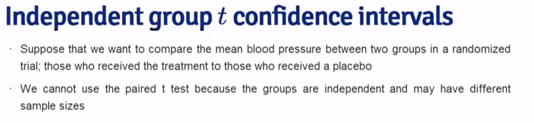

qownnotes-media-Fz1524

El objetivo de nuevo es encontrar el intervalo de confianza de la diferencia media de la presión arterial media entre ambos grupos con un 95% de posibilidad. Para hacer el cálculo de los intervalos de confianza vamos a trabajar restando la media de ambos conjuntos, el quantile se calcula en base a ambos conjuntos, ya que hemos calculado su media por separado, así que hay que restar 2 a la suma de ambos para obtener el grado de confianza de todo.

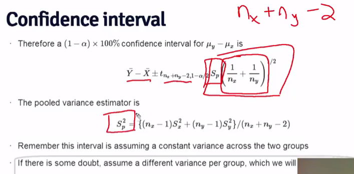

qownnotes-media-aV1524

La varianza común es más dificil de calcular, haremos una estimación media entre ambas varianzas aplicando pesos en cada una de ellas dependiento del tamaño de cada grupo diviendolo por el tamaño total. Se ve más claro en este ejemplo extraído del libro Fundamentals of Biostatistics. Primero haremos los cálculos suponiendo que las varianzas son equivalentes. Se puede observar que el intervalo de confianza sobre difrencia media de ambas presiones arteriales medias contiene el valor 0, por lo que no se puede descartar que las medias de ambos grupos sean iguales.

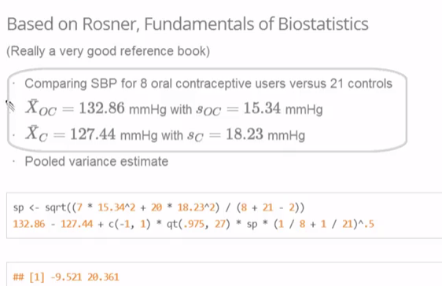

qownnotes-media-Tn1524

Aquí se puede apreciar el error de cálculo si tratamos el ejemplo anterior como grupos independientes

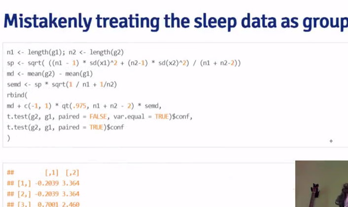

qownnotes-media-kP1524

Se puede apreciar en el cálculo de ambos casos que cuando los tratamos de manera distinta un cálculo contiene el 0 y el otro no lo contiene, lo que significa que cuando los grupos están emparejados tienen muchas más medias distintas, de manera opuesta a cuando no los emparejamos y los tratamos como independientes en que se contiene el valor 0 y por tanto las diferencias en las medias son menos distintas ya que se tratan todos los datos como un solo grupo.

La función t.test tiene otro parámetro con el que se puede jugar que es si la varianza de los datos es igual en ambos conjuntos. En este ejemplo, se intenta hacer un intervalo de confianza entre la ganancia de peso de pollos con 4 dietas, comparándolas de 2 en 2, en este ejmplo la 1 y la 4, cuya diferencia de variablidad es muy evidente a nivel gráfico.

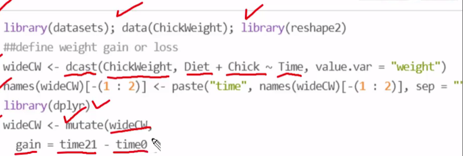

qownnotes-media-Bt1524

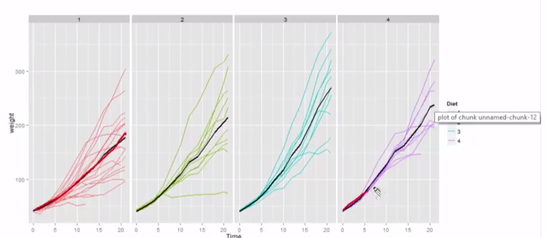

qownnotes-media-mA1524

vemos que los resultados de las estimaciones varían dependiendo del tratamiento de la relacción entre las varianzas de los grupos.

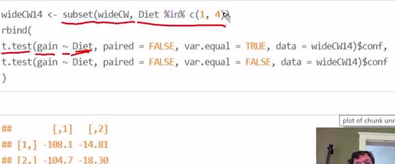

qownnotes-media-ll1524

DISTINTA VARIANZA ENTRE GRUPOS

En el caso de que la varianza de los grupos no sea la misma o no estemos seguros, En caso de duda, se debe utilizar varianza no es igual, para calcularala

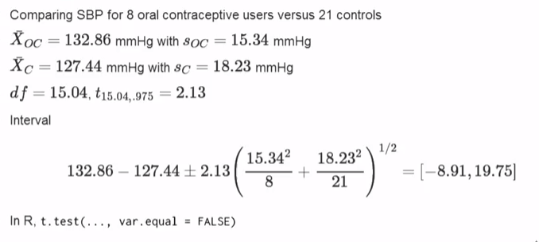

qownnotes-media-Mp1524

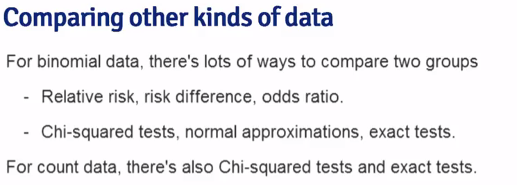

qownnotes-media-Rh1524

CHI SQUARE TEST

Este test se utiliza para saber si dos variables son independientes, es decir, si la aparición de una está relaccionada (ojo no es la causa, sólo si están relacconada) con la otra. Es apropiado utilizar este método en las siguientes situaciones:

- El muestreo es aleatorio
- las variables son categoricas
- si los datos recogidos en la tabla de contingencia tienen en las frecuencias esperadas al menos 5 casos.

Este método consiste en 4 pasos:

Establecer la hipótesis: Ho-> Variable A y variable B son independientes Ha-> Variable A y variable B no son independientes La hipótesis alternativa por tanto es que sabiendo el valor A nos puede ayudar a predecir el valor de B Formular el plan de análisis Este paso describe cómo usar muestras de los datos para aceptar o rechazar la hipótesis nula: Nivel de significancia elegir un nivel apropiado entre 0 y 1 Test a utilizar en este caso chi-cuadrado Analizar la muestra de los datos Grados de libertad DF = (r-1)(c-1) donde r son el nº de niveles de A y c el nº de niveles de B Frecuencia esperada = Son computadas por separado para cada nivel de cada variable en cada nivel de la otra variable Er,c = (nr*nc)/n Donde Er,c es la frecuencia esperada para el nivel r de la variable A y nivel c de la B nr es el número total de observaciones del nivel r en A nc es el número total de observaciones del nivel c en B n es el número total de la muestra Test estadístico = x2 = sum[(Or,c - Er,c)2/Er,c] Donde Or,c es la frecuencia del nivel r de la variable A y nivel C de la B Er,c es la frecuencia esperada del nivel r de la variable A y el nivel c de la B P-value = es la probabilidad de observar una muestra de manera aleatoria al menos tan extrema como la nuestra. Para poder conocer esta probabilidad, se debe calcular si la distribución pertenece a una chi-cuadrado, si es así, utilizar los grados de libertad anteriores y el test estadístico para obtener el pvalue de la muestra de datos.